# xwMOOC 모형 - `tidymodels`

`purrr` - 많은 모형(many models)

xwMOOC

Tidyverse Korea

2019-08-18

# 1 `gapminder` 회귀모형 [^1]

`purrr` 팩키지를 활용하여 원본 모형 데이터와 모형을 하나의 데이터프레임(`tibble`)에 담을 수가 있다. 즉, 6가지 서로 다른 회귀모형을 일괄적으로 적합시키고 가장 AIC 값이 적은 회귀모형을 선택하는 코드를 다음과 같이 작성한다.

1. `reg_models`: 다양한 회귀모형을 정의한다.
2. `mutate(map())`: 정의한 회귀모형 각각을 적합시키고 모형성능 지표를 추출한다.
3. AIC 기준으로 가장 낮은 모형을 선정한다.

```r
library(tidyverse)
library(gapminder)

## 데이터셋 준비 -----
gapminder <- gapminder %>%
  set_names(colnames(.) %>% tolower())

## 다양한 회귀모형 -----
reg_models <- list(
  `01_pop` = 'lifeexp ~ pop',
  `02_gdppercap` = 'lifeexp ~ gdppercap',
  `03_simple` = 'lifeexp ~ pop + gdppercap',
  `04_medium` = 'lifeexp ~ pop + gdppercap + continent + year',
  `05_more`   = 'lifeexp ~ pop + gdppercap + country + year',
  `06_full`   = 'lifeexp ~ pop + gdppercap + year*country')

model_tbl <- data_frame(reg_formula = reg_models) %>%
  mutate(model_name = names(reg_formula)) %>%
  select(model_name, reg_formula) %>%
  mutate(reg_formula = map(reg_formula, as.formula))

model_tbl
```

```
# A tibble: 6 x 2
  model_name   reg_formula
  <chr>        <named list>
1 01_pop       <formula>
2 02_gdppercap <formula>
3 03_simple    <formula>
4 04_medium    <formula>
5 05_more      <formula>
6 06_full      <formula>
```

```r
## 회귀모형 적합 및 모형 성능 지표 -----
model_tbl <- model_tbl %>%
  mutate(fit = map(reg_formula, ~lm(., data = gapminder), gapminder = gapminder)) %>%
  mutate(model_glance = map(fit, broom::glance),
         rsquare      = map_dbl(model_glance, ~.$r.squared),
         AIC          = map_dbl(model_glance, ~.$AIC)) %>%
  arrange(AIC)

model_tbl
```

```
# A tibble: 6 x 6
  model_name   reg_formula fit    model_glance      rsquare    AIC
  <chr>        <list>      <list> <list>              <dbl>  <dbl>
1 06_full      <formula>   <lm>   <tibble [1 x 11]> 0.976    7752.
2 05_more      <formula>   <lm>   <tibble [1 x 11]> 0.932    9268.
3 04_medium    <formula>   <lm>   <tibble [1 x 11]> 0.717   11420.
4 03_simple    <formula>   <lm>   <tibble [1 x 11]> 0.347   12836.
5 02_gdppercap <formula>   <lm>   <tibble [1 x 11]> 0.341   12850.
6 01_pop       <formula>   <lm>   <tibble [1 x 11]> 0.00422 13553.
```

# 2 교차검증 `CV`

데이터를 10조각내서 교차검정을 통해 RMSE가 가장 작은 회귀모형이 어떤 것인지 살펴보자. `cross_df()` 함수로 교차검증 `splits` 데이터와 모형을 준비한다. 다음으로 `analysis()` 함수로 교차검증 데이터에 대해서 회귀모형 각각을 적합시키고, `assessment()` 함수로 적합시킨 모형에 대해 모형성능을 살펴본다. 마지막으로 RMSE 회귀모형 성능지표를 통해 모형선택을 한다.

```r
## 교차검정 -----
valid_tbl <- gapminder %>%
  rsample::vfold_cv(10)

cv_tbl <- list(test_training = list(valid_tbl),
               model_name = model_tbl$model_name)

cv_tbl <- cross_df(cv_tbl) %>%
  unnest(.id = "model_number") %>%
  left_join(model_tbl %>% select(model_name, reg_formula), by = "model_name")

cv_tbl
```

```
# A tibble: 60 x 5
   model_name model_number splits             id     reg_formula
   <chr>      <chr>        <list>             <chr>  <list>
 1 06_full    1            <split [1.5K/171]> Fold01 <formula>
 2 06_full    1            <split [1.5K/171]> Fold02 <formula>
 3 06_full    1            <split [1.5K/171]> Fold03 <formula>
 4 06_full    1            <split [1.5K/171]> Fold04 <formula>
 5 06_full    1            <split [1.5K/170]> Fold05 <formula>
 6 06_full    1            <split [1.5K/170]> Fold06 <formula>
 7 06_full    1            <split [1.5K/170]> Fold07 <formula>
 8 06_full    1            <split [1.5K/170]> Fold08 <formula>
 9 06_full    1            <split [1.5K/170]> Fold09 <formula>
10 06_full    1            <split [1.5K/170]> Fold10 <formula>
# ... with 50 more rows
```

```r
## 교차검정 analysis, assessment -----
cv_fit_tbl <- cv_tbl %>%
  mutate(fit = map2(reg_formula, splits, ~lm(.x, data = rsample::analysis(.y)))) %>%
  mutate(RMSE = map2_dbl(fit, splits, ~modelr::rmse(.x, rsample::assessment(.y))))

cv_fit_tbl
```

```
# A tibble: 60 x 7
   model_name model_number splits            id     reg_formula fit    RMSE
   <chr>      <chr>        <list>            <chr>  <list>      <lis> <dbl>
 1 06_full    1            <split [1.5K/171~ Fold01 <formula>   <lm>   2.44
 2 06_full    1            <split [1.5K/171~ Fold02 <formula>   <lm>   2.52
 3 06_full    1            <split [1.5K/171~ Fold03 <formula>   <lm>   3.38
 4 06_full    1            <split [1.5K/171~ Fold04 <formula>   <lm>   1.99
 5 06_full    1            <split [1.5K/170~ Fold05 <formula>   <lm>   2.40
 6 06_full    1            <split [1.5K/170~ Fold06 <formula>   <lm>   2.64
 7 06_full    1            <split [1.5K/170~ Fold07 <formula>   <lm>   2.55
 8 06_full    1            <split [1.5K/170~ Fold08 <formula>   <lm>   2.28
 9 06_full    1            <split [1.5K/170~ Fold09 <formula>   <lm>   2.66
10 06_full    1            <split [1.5K/170~ Fold10 <formula>   <lm>   2.73
# ... with 50 more rows
```

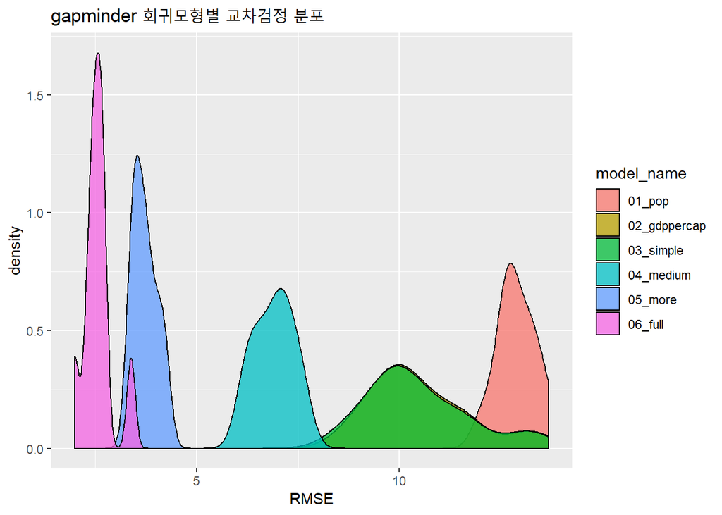

```r
## 시각화 -----
cv_fit_tbl %>%
  ggplot(aes(RMSE, fill = model_name)) +
  geom_density(alpha = 0.75) +
  labs(x = "RMSE", title = "gapminder 회귀모형별 교차검정 분포")
```

# 3 병렬처리 - `furrr`

```r
library(furrr)
library(tictoc)

plan(multiprocess(workers = parallel::detectCores()-1))
```

**`purrr` 순차처리**

```r
## purrr 순차처리 -----
tic()

cv_fit_tbl <- cv_tbl %>%
  mutate(fit = map2(reg_formula, splits, ~lm(.x, data = rsample::analysis(.y))))

toc()
```

```
1.21 sec elapsed
```

**`furrr` 병렬처리**

```r
## furrr 병렬처리 ----
tic()

cv_fit_tbl <- cv_tbl %>%
  mutate(fit = future_map2(reg_formula, splits, ~lm(.x, data = rsample::analysis(.y)), .progress=TRUE))
```

```
 Progress: ───────────────────────────────────────────────────────────────── 100%
```

```r
toc()
```

```
2.31 sec elapsed
```

[^1]: [DAN OVANDO(FEBRUARY 20, 2018), “DATA WRANGLING AND MODEL FITTING USING PURRR”](https://www.weirdfishes.blog/blog/practical-purrr/)